# phsmethods R Package

25 February 2020  
Slides: https://github.com/jackhannah95/phsmethods-useR

## Why write [{phsmethods}](https://github.com/Health-SocialCare-Scotland/phsmethods)?

- Benefit to PHS: lots of analysts do the same things in different ways - it's a waste of time and effort and causes inconsistencies
- Benefit to developers and contributors: to learn how to write a 'real' package

## file_size()

```r
# All files in the data folder
file_size(here::here("2020-02-25_phsmethods", "data"))
```

```
## # A tibble: 5 x 2
##   name                   size
##   <chr>                  <chr>
## 1 2019-11-12-Table1.xlsx Excel 49 KB
## 2 2019-11-12-Table2.xlsx Excel 258 KB
## 3 2019-11-12-Table3.xlsx Excel 92 KB
## 4 iris.csv               CSV 4 KB
## 5 mtcars.sav             SPSS 4 KB
```

## file_size()

```r
# Excel files only
file_size(here::here("2020-02-25_phsmethods", "data"),
          pattern = ".xlsx$")
```

```
## # A tibble: 3 x 2
##   name                   size
##   <chr>                  <chr>
## 1 2019-11-12-Table1.xlsx Excel 49 KB
## 2 2019-11-12-Table2.xlsx Excel 258 KB
## 3 2019-11-12-Table3.xlsx Excel 92 KB
```

## file_size() in practice

This is the 'List of Tables' section from page 25 of the [2019-11-12 HSMR publication](https://www.isdscotland.org/Health-Topics/Quality-Indicators/Publications/2019-11-12/2019-11-12-HSMR-Report.pdf):

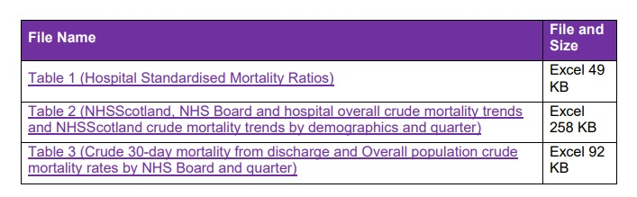

## Recreate using file_size and [{gt}](https://github.com/rstudio/gt)

```r
file_size(here::here("2020-02-25_phsmethods", "data"),
          pattern = ".xlsx?$") %>%
  mutate(name = pub_text) %>%
  gt() %>%
  tab_style(style = cell_borders(),
            locations = cells_body(columns = everything(),
                                   rows = everything())) %>%
  tab_style(style = cell_text(color = "white", weight = "bolder"),
            locations = cells_column_labels(columns = everything())) %>%
  tab_style(style = cell_text(color = "purple",
                              decorate = "underline"),
            locations = cells_body(columns = vars(name))) %>%
  tab_style(style = cell_text(weight = "bold"),
            locations = cells_body(columns = vars(name, size))) %>%
  tab_style(style = cell_fill(color = "darkorchid4"),
            locations = cells_column_labels(columns = everything())) %>%
  cols_width(vars(name) ~ px(620), TRUE ~ px(75)) %>%
  cols_label(name = "File Name", size = "File and Size")
```

## Recreate using file_size and [{gt}](https://github.com/rstudio/gt)

| File Name | File and Size |
| --- | --- |
| Table 1 (Hospital Standardised Mortality Ratios) | Excel 49 KB |
| Table 2 (NHSScotland, NHS Board and hospital overall crude mortality trends and NHSScotland crude mortality trends by demographics and quarter) | Excel 258 KB |
| Table 3 (Crude 30-day mortality from discharge and Overall population crude mortality rates by NHS Board and quarter) | Excel 92 KB |

## fin_year() and qtr() functions

```r
lubridate::today()
```

```
## [1] "2021-06-22"
```

```r
fin_year(lubridate::today())
```

```
## [1] "2021/22"
```

```r
qtr(lubridate::today())
```

```
## [1] "April to June 2021"
```

```r
qtr(lubridate::today(), format = "short")
```

```
## [1] "Apr-Jun 2021"
```

## fin_year() and qtr() in RMarkdown

This is from the 'Main Points' section of the [2019-11-26 Smoking Cessation Services summary report](https://www.isdscotland.org/Health-Topics/Public-Health/Publications/2019-11-26/2019-11-26-SmokingCessationLDPstandard-Summary.pdf?):

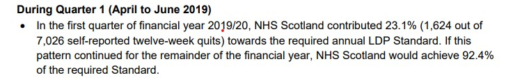

## fin_year() and qtr() in RMarkdown

In RMarkdown:

```r
data_end <- lubridate::dmy(30062019)
```

During Quarter **1** **(April to June 2019)**  
• In the **first** quarter of financial year **2019/20**, NHS Scotland contributed 23.1% (1,624 out of 7,026 self-reported twelve-week quits) towards the required annual LDP Standard. If this pattern continued for the remainder of the financial year, NHS Scotland would achieve 92.4% of the required Standard.

## fin_year() and qtr() in RMarkdown

In RMarkdown:

```r
data_end <- lubridate::dmy(30062019)
```

**During Quarter `` `r lubridate::quarter(data_end, fiscal_start = 4)` `` `` `r paste0("(", qtr(data_end), ")")` ``**  
`` `r "\U2022"` `` In the `` `r english::ordinal(lubridate::quarter(data_end, fiscal_start = 4))` `` quarter of financial year `` `r fin_year(data_end)` ``, NHS Scotland contributed 23.1% (1,624 out of 7,026 self-reported twelve-week quits) towards the required annual LDP Standard. If this pattern continued for the remainder of the financial year, NHS Scotland would achieve 92.4% of the required Standard.

## Other functions in phsmethods

- `postcode()` formats improperly recorded postcodes
- `qtr_end()` calculates the final month in a quarter
- `qtr_next()` calculates the next quarter
- `qtr_prev()` calculates the previous quarter

## Future developments

- The package needs a new maintainer - I'm leaving in April
- Contributions from others in PHS - development is under way to develop functions to group ages into age bands and to turn geography codes into names
- Build a [{pkgdown}](https://pkgdown.r-lib.org/) website?
- Create functions for agreed-upon methodologies by the 'new SAG'

## Contact and Links

- Email: jack.hannah1@nhs.net
- GitHub: jackhannah95
- [phsmethods GitHub repository](https://github.com/Health-SocialCare-Scotland/phsmethods)
- [Blogpost](https://www.tidyverse.org/blog/2017/08/contributing/) by Jim Hester on contributing to open source software